# BCB420 Assignment 1: RNA-seq Data Analysis

Victoria Pergola

2026-02-10

## Dataset Overview and Motivation

### Study Background

I selected the bulk RNA-seq dataset GSE255359 from Quintela-Fandino et al (2024), which investigates nintedanib (an anti-fibrotic drug) combined with paclitaxel chemotherapy in HER2-negative breast cancer patients. The study examines how tumour extracellular matrix stiffness affects treatment response and whether anti-fibrotic intervention can improve outcomes.

I have been particularly interested in cancer drug research as there are direct implications for patient outcomes. This dataset offers a unique window into how anti-fibrotic therapy reshapes the tumour microenvironment at the transcriptional level, potentially revealing mechanisms of treatment resistance and response in breast cancer. Understanding the molecular changes induced by combining anti-fibrotic agents with chemotherapy could inform future therapeutic strategies and biomarker development for predicting treatment response.

### Experimental Design

**Conditions analyzed:**

- **Baseline:** Pre-treatment tumour biopsies (before any therapy)
- **Post-treatment:** tumour samples after neoadjuvant therapy with paclitaxel ± nintedanib

## Package Installation and Loading

First I will install and load all the relevant packages needed for analysis of the dataset.

```r
# Install CRAN packages
cran_packages <- c("knitr", "dplyr", "readr", "rmarkdown", "tidyr",
                   "patchwork", "ggplot2", "ggrepel", "ComplexHeatmap",
                   "circlize", "tibble", "RColorBrewer", "pheatmap")

for(pkg in cran_packages) {
  if(!requireNamespace(pkg, quietly = TRUE)) {
    install.packages(pkg)
  }
}

# Install Bioconductor packages
if(!requireNamespace("BiocManager", quietly = TRUE)) {
  install.packages("BiocManager")
}

bioc_packages <- c("biomaRt", "GEOquery", "edgeR")
for(pkg in bioc_packages) {
  if(!requireNamespace(pkg, quietly = TRUE)) {
    BiocManager::install(pkg)
  }
}
```

```r
# Load all required libraries
library(GEOquery)
library(readr)
library(rmarkdown)
library(knitr)
library(dplyr)
library(biomaRt)
library(edgeR)
library(ggplot2)
library(tidyr)
library(patchwork)
library(ggrepel)
library(ComplexHeatmap)
library(circlize)
library(pheatmap)
library(tibble)
```

## Data Acquisition from GEO

Here I use GEOquery to pull the data from the GEO database.

```r
# Download supplementary files from GEO
if(!file.exists("GSE255359/GSE255359_RAW_RNAseq_counts.csv.gz")) {
  getGEOSuppFiles("GSE255359", makeDirectory = TRUE)
}

# Load raw count matrix
raw_counts <- read_csv("GSE255359/GSE255359_RAW_RNAseq_counts.csv.gz",
                       show_col_types = FALSE)

# Preview
paged_table(raw_counts[1:10, 1:10])
```

| geneID | mjb-03-001 | mjb-136-006 | mjb-136-009 | mjb-136-011 | mjb-136-012 | mjb-136-013 | mjb-136-014 | mjb-136-015 | mjb-137-001 |
| --- | --- | --- | --- | --- | --- | --- | --- | --- | --- |
| ENSG00000223972.5 | 0 | 0 | 0 | 0 | 0 | 0 | 0 | 0 | 0 |
| ENSG00000227232.5 | 0 | 0 | 0 | 0 | 1 | 0 | 0 | 1 | 2 |
| ENSG00000278267.1 | 0 | 0 | 0 | 0 | 0 | 0 | 0 | 0 | 0 |
| ENSG00000243485.5 | 0 | 0 | 0 | 0 | 0 | 0 | 0 | 0 | 0 |
| ENSG00000284332.1 | 0 | 0 | 0 | 0 | 0 | 0 | 0 | 0 | 0 |
| ENSG00000237613.2 | 0 | 0 | 0 | 0 | 0 | 0 | 0 | 0 | 0 |
| ENSG00000268020.3 | 0 | 0 | 0 | 0 | 0 | 0 | 0 | 0 | 0 |
| ENSG00000240361.2 | 0 | 0 | 0 | 0 | 0 | 0 | 0 | 0 | 0 |
| ENSG00000186092.7 | 0 | 0 | 0 | 0 | 0 | 0 | 0 | 0 | 0 |
| ENSG00000238009.6 | 1 | 9 | 4 | 9 | 16 | 4 | 15 | 12 | 22 |

## Initial Quality Assessment

### Sample Metadata and Library Sizes

Next, I will inspect the number of samples that the data set contains for each condition as well as library size.

```r
# Prepare count matrix
counts <- raw_counts[, -1]
rownames(counts) <- raw_counts$geneID

# Create sample metadata from column names
sample_names <- colnames(counts)
samples <- data.frame(
  sample = sample_names,
  condition = ifelse(grepl("POST", sample_names), "Post_Treatment", "Baseline"),
  row.names = sample_names,
  stringsAsFactors = FALSE
)
samples$condition <- factor(samples$condition)

# Calculate library sizes
lib_sizes <- colSums(counts, na.rm = TRUE)
lib_sizes_df <- data.frame(
  sample = names(lib_sizes),
  library_size = lib_sizes
)

# Summary statistics by condition
lib_summary <- lib_sizes_df %>%
  left_join(samples, by = "sample") %>%
  group_by(condition) %>%
  summarise(
    n_samples = n(),
    mean_lib_size = mean(library_size),
    sd_lib_size = sd(library_size),
    min_lib_size = min(library_size),
    max_lib_size = max(library_size),
    cv_percent = round(100 * sd(library_size) / mean(library_size), 1),
    .groups = "drop"
  )

paged_table(lib_summary)
```

| condition | n_samples | mean_lib_size | sd_lib_size | min_lib_size | max_lib_size | cv_percent |
| --- | --- | --- | --- | --- | --- | --- |
| Baseline | 76 | 6277398 | 1131283.0 | 3396582 | 12146350 | 18.0 |
| Post_Treatment | 32 | 6891044 | 768536.8 | 4609286 | 8125499 | 11.2 |

**Table 2: Sequencing depth summary.** Library sizes (total read counts per sample) grouped by experimental condition. The coefficient of variation (CV) quantifies the relative variability within each group—values below 25% indicate acceptable consistency in sequencing depth. Both conditions show consistent sequencing depth with no extreme outliers, suggesting uniform sample processing and library preparation quality.

The dataset contains **108 samples** across two conditions: 76 baseline and 32 post-treatment samples. Library sizes range from 3,396,582 to 12,146,350 reads per sample, with a mean of 6,459,219 reads.

#### Outlier analysis

No outliers were identified based on library size distribution. All samples demonstrate adequate sequencing depth with coefficients of variation below 25% within each condition, indicating good technical reproducibility. The original publication did not report removing any samples, and our quality assessment supports retaining all samples for analysis. This consistency across 108 samples reflects careful experimental design and execution.

### Library Size Distribution

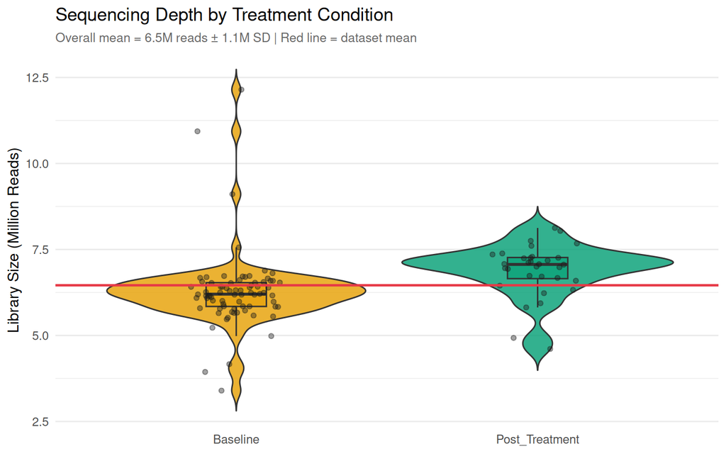

```r
# Prepare data for plotting
lib_plot_df <- lib_sizes_df %>%
  left_join(samples, by = "sample")

mean_lib <- mean(lib_plot_df$library_size)
sd_lib <- sd(lib_plot_df$library_size)

# Violin plot with better colors
ggplot(lib_plot_df, aes(x = condition, y = library_size/1e6, fill = condition)) +
  geom_violin(alpha = 0.8, trim = FALSE, color = "grey20") +
  geom_boxplot(width = 0.2, alpha = 0.6, outlier.shape = NA, color = "grey20") +
  geom_jitter(width = 0.15, alpha = 0.4, size = 1.5, color = "grey10") +
  geom_hline(yintercept = mean_lib/1e6,
             linetype = "solid",
             color = "#E63946",
             linewidth = 0.9) +
  scale_fill_manual(values = condition_colors) +
  theme_minimal(base_size = 12) +
  theme(
    legend.position = "none",
    axis.title.x = element_blank(),
    panel.grid.major.x = element_blank(),
    plot.subtitle = element_text(size = 10, color = "grey40")
  ) +
  labs(
    title = "Sequencing Depth by Treatment Condition",
    subtitle = paste0("Overall mean = ", round(mean_lib/1e6, 1),
                     "M reads ± ", round(sd_lib/1e6, 1), "M SD | Red line = dataset mean"),
    y = "Library Size (Million Reads)"
  )
```

**Figure 1: Library size distribution by condition.** Violin plots display the probability density of library sizes for baseline (orange) and post-treatment (green) samples. Each violin shows the full distribution shape, with an overlaid boxplot indicating median and quartiles. Individual samples are shown as jittered points. The horizontal red line marks the overall mean across all samples.

#### Replicate handling strategy

All samples are treated as independent biological replicates rather than being averaged within conditions. This preserves individual sample variability and maximizes statistical power for differential expression testing. The edgeR framework explicitly models within-group variance using these replicates, employing empirical Bayes methods to share information across genes for more stable variance estimates. By maintaining all individual samples, we can detect treatment effects while accounting for patient-to-patient variability, which is particularly important in clinical samples where biological heterogeneity is expected.

## Gene Identifier Mapping

### Mapping Ensembl IDs to HUGO Symbols

The raw data uses Ensembl gene identifiers (e.g., ENSG00000000003.15). I will map these to HUGO gene symbols using the biomaRt annotation database, which provides access to the most current gene nomenclature. HUGO symbols are the standardized gene names used in publications and databases, making results more interpretable and facilitating downstream pathway analysis.

```r
# Extract gene IDs
gene_ids <- rownames(counts)

# Clean version numbers from Ensembl IDs (e.g., ENSG00000000003.15 -> ENSG00000000003)
gene_ids_clean <- gsub("\\..*", "", gene_ids)

# Connect to Ensembl biomaRt
ensembl <- useMart("ensembl", dataset = "hsapiens_gene_ensembl")

# Query for HUGO symbols
gene_mapping <- getBM(
  attributes = c("ensembl_gene_id", "hgnc_symbol"),
  filters = "ensembl_gene_id",
  values = gene_ids_clean,
  mart = ensembl
)

# Restore version numbers for matching
gene_mapping$ensembl_gene_id_version <- gene_ids[match(
  gene_mapping$ensembl_gene_id,
  gene_ids_clean
)]

# Mapping statistics
total_genes <- length(gene_ids)
mapped_genes <- nrow(gene_mapping)
valid_symbols <- sum(gene_mapping$hgnc_symbol != "" & !is.na(gene_mapping$hgnc_symbol))
unmapped_genes <- total_genes - mapped_genes

knitr::asis_output(sprintf(
"**Mapping results**

- Total genes: %d
- Successfully mapped: %d (%.1f%%)
- Valid HUGO symbols: %d (%.1f%%)
- Failed to map: %d (%.1f%%)",
  total_genes,
  mapped_genes, 100 * mapped_genes / total_genes,
  valid_symbols, 100 * valid_symbols / total_genes,
  unmapped_genes, 100 * unmapped_genes / total_genes
))
```

**Mapping results**

- Total genes: 60708
- Successfully mapped: 59458 (97.9%)
- Valid HUGO symbols: 41276 (68.0%)
- Failed to map: 1250 (2.1%)

#### Successful mappings

97.9% of genes successfully mapped to the biomaRt database, with 68% receiving valid HUGO symbols.

The 97.9% mapping rate to biomaRt indicates that nearly all Ensembl IDs in our dataset correspond to current gene annotations. However, only 68% received official HUGO symbols. This discrepancy is expected and biologically meaningful: not all genes have approved HUGO symbols such as predicted genes awaiting validation, or recently discovered loci not yet incorporated into official nomenclature. The remaining ~30% of mapped genes without HUGO symbols (those that mapped to biomaRt but lack hgnc_symbol annotations) likely represent non-coding RNAs and unannotated genes that are still detectable in the transcriptome but not yet officially named.

```r
# Show examples
gene_mapping[1:15, c("ensembl_gene_id_version", "hgnc_symbol")] %>%
  paged_table()
```

|  | ensembl_gene_id_version | hgnc_symbol |
| --- | --- | --- |
| 1 | ENSG00000000457.14 | SCYL3 |
| 2 | ENSG00000000460.17 | FIRRM |
| 3 | ENSG00000000938.13 | FGR |
| 4 | ENSG00000000971.16 | CFH |
| 5 | ENSG00000001460.18 | STPG1 |
| 6 | ENSG00000001461.17 | NIPAL3 |
| 7 | ENSG00000004455.17 | AK2 |
| 8 | ENSG00000004487.17 | KDM1A |
| 9 | ENSG00000006555.11 | TTC22 |
| 10 | ENSG00000007341.19 | ST7L |

[output cut: 5 more lines]

**Table 3: Example gene identifier mappings.** Sample of Ensembl gene IDs (left) with corresponding HUGO gene symbols (right). Empty cells in the HUGO column indicate genes without official symbols (often non-coding RNAs or predicted genes). Table truncated to first 15 genes for display purposes.

### Unmapped Genes

```r
# Identify unmapped genes
unmapped_list <- gene_ids[!gene_ids %in% gene_mapping$ensembl_gene_id_version]

# Show examples
data.frame(
  Ensembl_ID = head(unmapped_list, 10),
  Status = "No HUGO mapping found"
) %>%
  paged_table()
```

| Ensembl_ID | Status |
| --- | --- |
| ENSG00000238009.6 | No HUGO mapping found |
| ENSG00000288531.1 | No HUGO mapping found |
| ENSG00000230699.2 | No HUGO mapping found |
| ENSG00000241180.1 | No HUGO mapping found |
| ENSG00000236948.2 | No HUGO mapping found |
| ENSG00000226849.1 | No HUGO mapping found |
| ENSG00000272482.1 | No HUGO mapping found |
| ENSG00000224621.1 | No HUGO mapping found |
| ENSG00000234166.1 | No HUGO mapping found |
| ENSG00000261135.1 | No HUGO mapping found |

**Table 4: Examples of unmapped gene identifiers.** Ten representative Ensembl IDs that could not be mapped to current HUGO symbols. These likely represent deprecated identifiers, non-coding RNAs without official symbols, or genes removed from recent database versions.

The 1250 unmapped genes (2.1%) likely fall into several categories: (1) deprecated Ensembl IDs that have been retired or merged with other entries in newer database versions, (2) predicted genes that failed validation and were removed from annotations, (3) assembly artifacts from earlier genome builds, or (4) very recently discovered loci not yet in the biomaRt version accessed. These genes are excluded from downstream analysis to ensure we work with reliably annotated features. This exclusion is standard practice and unlikely to substantially impact biological conclusions, as these unmapped features typically represent low-confidence gene models rather than well-characterized functional genes.

### Handling Duplicate Mappings

Some HUGO symbols map to multiple Ensembl IDs. Here I identify and aggregate these cases to ensure one-to-one mapping between gene symbols and expression values.

```r
# Filter for valid HUGO symbols
gene_mapping_valid <- gene_mapping %>%
  filter(hgnc_symbol != "" & !is.na(hgnc_symbol))

# Find duplicates
dup_hugo <- gene_mapping_valid %>%
  group_by(hgnc_symbol) %>%
  filter(n() > 1) %>%
  arrange(hgnc_symbol) %>%
  ungroup()

cat("HUGO symbols with multiple Ensembl IDs:",
    length(unique(dup_hugo$hgnc_symbol)), "\n\n")
```

```
## HUGO symbols with multiple Ensembl IDs: 19
```

```r
# Show examples
if(nrow(dup_hugo) > 0) {
  dup_hugo[1:min(15, nrow(dup_hugo)), c("hgnc_symbol", "ensembl_gene_id_version")] %>%
    paged_table()
}
```

| hgnc_symbol | ensembl_gene_id_version |
| --- | --- |
| CYP4F30P | ENSG00000214081.8 |
| CYP4F30P | ENSG00000282944.1 |
| DHRS4L1 | ENSG00000225766.10 |
| DHRS4L1 | ENSG00000285467.1 |
| DUXAP8 | ENSG00000206195.11 |
| DUXAP8 | ENSG00000271672.1 |
| ECEL1P2 | ENSG00000224516.5 |
| ECEL1P2 | ENSG00000244280.1 |
| FRG1BP | ENSG00000149531.15 |
| FRG1BP | ENSG00000287288.1 |

[output cut: 5 more lines]

**Table 5: Genes with non-unique mappings.** HUGO symbols that map to multiple Ensembl gene IDs. For these cases, counts are summed across all Ensembl IDs to obtain total gene-level expression.

#### Aggregation strategy and biological justification

When multiple Ensembl IDs map to the same HUGO symbol, I sum their read counts. This approach is justified because alternative transcript isoforms from the same gene locus should be aggregated to represent total gene expression, summing counts preserves the total number of reads and maintains count-based statistical properties needed for edgeR, and this is a standard and conservative approach in RNA-seq analysis. Alternative approaches like selecting the longest transcript or averaging would either discard data or break count-based statistical assumptions. The 19 genes requiring aggregation represent a small fraction of the dataset.

```r
# Add Ensembl IDs to count matrix
counts_with_symbols <- counts
counts_with_symbols$ensembl_id <- rownames(counts)
counts_with_symbols$ensembl_id_clean <- gsub("\\..*", "", counts_with_symbols$ensembl_id)

# Join with mapping
counts_mapped <- counts_with_symbols %>%
  left_join(
    gene_mapping_valid %>%
      dplyr::select(ensembl_gene_id, hgnc_symbol) %>%
      distinct(),
    by = c("ensembl_id_clean" = "ensembl_gene_id")
  ) %>%
  filter(!is.na(hgnc_symbol))

# Aggregate by HUGO symbol (sum duplicates)
counts_final <- counts_mapped %>%
  dplyr::select(-ensembl_id, -ensembl_id_clean) %>%
  group_by(hgnc_symbol) %>%
  summarise(across(everything(), sum), .groups = "drop") %>%
  as.data.frame()

rownames(counts_final) <- counts_final$hgnc_symbol
counts_final <- counts_final %>% dplyr::select(-hgnc_symbol)

cat("Final count matrix:\n")
```

```
## Final count matrix:
```

```r
cat("Genes (unique HUGO symbols):", nrow(counts_final), "\n")
```

```
## Genes (unique HUGO symbols): 41257
```

```r
cat("Samples:", ncol(counts_final), "\n")
```

```
## Samples: 108
```

```r
cat("Coverage:", round(100*nrow(counts_final)/nrow(counts), 1), "% of original genes\n")
```

```
## Coverage: 68 % of original genes
```

After mapping and aggregation, we retain 68% of the original genes. This represents the well-annotated, protein-coding and functional non-coding portion of the transcriptome. The loss of ~32% of features is expected and appropriate, primarily representing unannotated genes, pseudogenes, and low-confidence predictions that would add noise rather than biological signal to downstream analyses.

## Normalization and Filtering

### TMM Normalization Method

I apply **TMM (Trimmed Mean of M-values) normalization** using edgeR. TMM calculates scaling factors that correct for:

- Differences in sequencing depth between samples (library size effects)
- Compositional bias (where a few highly expressed genes dominate the library and suppress other genes’ relative representation)

#### Why TMM over alternatives?

- **vs RPKM/FPKM:** TMM doesn’t assume gene length is the primary normalization issue (gene length is constant across samples), making it more appropriate for between-sample comparisons
- **vs Quantile normalization:** TMM preserves true biological differences instead of forcing identical distributions across samples, which is critical when comparing different treatment conditions expected to have real expression differences
- **vs Simple CPM:** TMM is robust to composition bias from extreme gene expression changes, which is essential in cancer samples where oncogenes or tumour suppressors may be dramatically altered

TMM is the recommended normalization method for RNA-seq differential expression and is used by both edgeR and limma-voom pipelines. It has been extensively validated for clinical and biological datasets.

### Low-Expression Filtering

Before normalization, I remove genes with insufficient counts using `filterByExpr()`. This function retains genes with at least ~10 counts in a minimum number of samples (determined by the smallest group size, which in this case is the post-treatment group with 32 samples).

#### Rationale for filtering

- **Statistical power:** Removing lowly expressed genes reduces the number of statistical tests, decreasing the multiple testing burden and improving power to detect truly differentially expressed genes
- **Estimation stability:** Genes with very low counts have unstable variance estimates that can dominate dispersion calculations
- **Biological interpretability:** Genes consistently expressed at <10 counts are often noise or sporadic expression events rather than functionally relevant transcription

```r
# Create DGEList object
dge <- DGEList(counts = as.matrix(counts_final), group = samples$condition)

cat("Before filtering:", nrow(dge), "genes\n")
```

```
## Before filtering: 41257 genes
```

```r
# Filter low-expression genes
keep <- filterByExpr(dge, group = samples$condition)
dge_filtered <- dge[keep, , keep.lib.sizes = FALSE]

cat("After filtering:", nrow(dge_filtered), "genes\n")
```

```
## After filtering: 16413 genes
```

```r
cat("Removed:", sum(!keep), "genes (",
    round(100*sum(!keep)/nrow(dge), 1), "% of mapped genes)\n\n")
```

```
## Removed: 24844 genes ( 60.2 % of mapped genes)
```

```r
# Apply TMM normalization
dge_filtered <- calcNormFactors(dge_filtered, method = "TMM")

# Extract normalized CPM values
normalised_counts <- cpm(dge_filtered)
```

#### TMM normalization factors

The first six samples have normalization factors:  
1.075, 0.991, 1.055, 1.185, 0.871, 0.936.

Across all samples, the normalization factors range from  
0.778 to  
1.195,  
with a mean of 1.004.  
Values close to 1.0 indicate well-balanced samples.

#### Final dataset coverage

After identifier mapping and low-expression filtering, the analysis includes **16413 genes** across **108 samples**, representing 27% of the original gene set. This final dataset comprises reliably detectable, well-annotated genes with sufficient expression for robust statistical testing—representing the functionally active portion of the transcriptome in these breast cancer samples.

```r
# Preview normalized data
normalised_counts[1:10, 1:8] %>%
  round(2) %>%
  kable()
```

|  | mjb-03-001 | mjb-136-006 | mjb-136-009 | mjb-136-011 | mjb-136-012 | mjb-136-013 | mjb-136-014 | mjb-136-015 |
| --- | --- | --- | --- | --- | --- | --- | --- | --- |
| A1BG-AS1 | 7.27 | 26.23 | 15.76 | 16.19 | 10.15 | 11.01 | 4.15 | 16.07 |
| A2M | 68.39 | 213.78 | 203.63 | 85.78 | 64.10 | 205.26 | 92.17 | 76.19 |
| A2M-AS1 | 5.19 | 9.37 | 2.75 | 1.66 | 3.95 | 1.92 | 4.15 | 20.71 |
| A2ML1 | 0.74 | 0.94 | 0.31 | 2.57 | 1.69 | 0.35 | 0.86 | 1.85 |
| A2ML1-AS1 | 1.34 | 2.25 | 1.84 | 1.97 | 4.70 | 0.87 | 2.15 | 1.24 |
| A2MP1 | 4.90 | 6.56 | 5.66 | 5.45 | 4.70 | 6.64 | 4.58 | 5.25 |
| A4GALT | 3.41 | 7.12 | 6.27 | 10.89 | 7.33 | 9.61 | 5.01 | 4.02 |
| AAAS | 9.35 | 6.75 | 5.35 | 5.45 | 4.70 | 3.49 | 7.59 | 5.10 |
| AACS | 29.82 | 36.72 | 22.18 | 20.73 | 58.27 | 25.68 | 26.91 | 26.12 |
| AADACL2-AS1 | 61.86 | 38.78 | 160.33 | 41.15 | 22.37 | 93.81 | 29.91 | 22.56 |

**Table 6: TMM-normalized expression values (CPM).** Preview of counts-per-million values after TMM normalization. These values are library-size and composition-bias corrected, enabling direct comparison across samples. CPM values can be interpreted as the number of reads per million total reads in the library, adjusted for compositional differences. Table shows first 10 genes and 8 samples.

### Normalization Effect Visualization

Given the large sample count (108), density plots effectively show the normalization effect across all samples simultaneously, revealing how TMM correction aligns sample distributions while preserving biological variation.

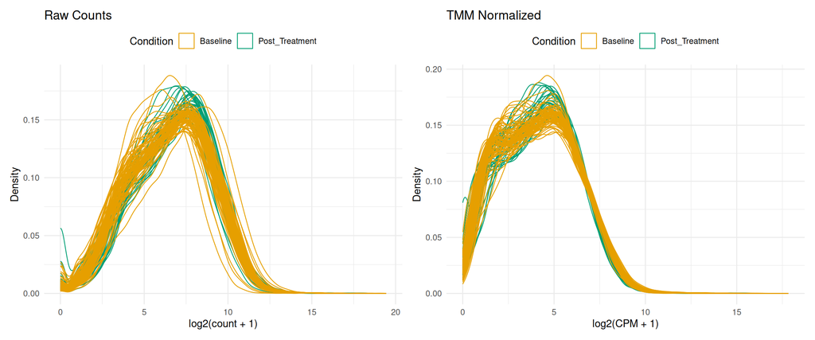

```r
# Prepare data for visualization
counts_filtered_raw <- counts_final[rownames(dge_filtered), ]

raw_long <- as.data.frame(counts_filtered_raw) %>%
  mutate(gene = rownames(counts_filtered_raw)) %>%
  pivot_longer(-gene, names_to = "sample", values_to = "count") %>%
  left_join(samples, by = "sample")

norm_long <- as.data.frame(normalised_counts) %>%
  mutate(gene = rownames(normalised_counts)) %>%
  pivot_longer(-gene, names_to = "sample", values_to = "count") %>%
  left_join(samples, by = "sample")

# Density plots
p_raw <- ggplot(raw_long, aes(x = log2(count + 1), group = sample, color = condition)) +
  geom_density(alpha = 0.5, linewidth = 0.4) +
  scale_color_manual(values = condition_colors) +
  theme_minimal(base_size = 11) +
  theme(legend.position = "top") +
  labs(
    title = "Raw Counts",
    x = "log2(count + 1)",
    y = "Density",
    color = "Condition"
  )

p_norm <- ggplot(norm_long, aes(x = log2(count + 1), group = sample, color = condition)) +
  geom_density(alpha = 0.5, linewidth = 0.4) +
  scale_color_manual(values = condition_colors) +
  theme_minimal(base_size = 11) +
  theme(legend.position = "top") +
  labs(
    title = "TMM Normalized",
    x = "log2(CPM + 1)",
    y = "Density",
    color = "Condition"
  )

p_raw + p_norm
```

## Sample Quality Control

### Correlation Analysis

High correlation between biological replicates indicates good technical reproducibility and consistent sample quality. Correlation analysis serves as a quality control metric to identify potential sample swaps, outliers, or batch effects.

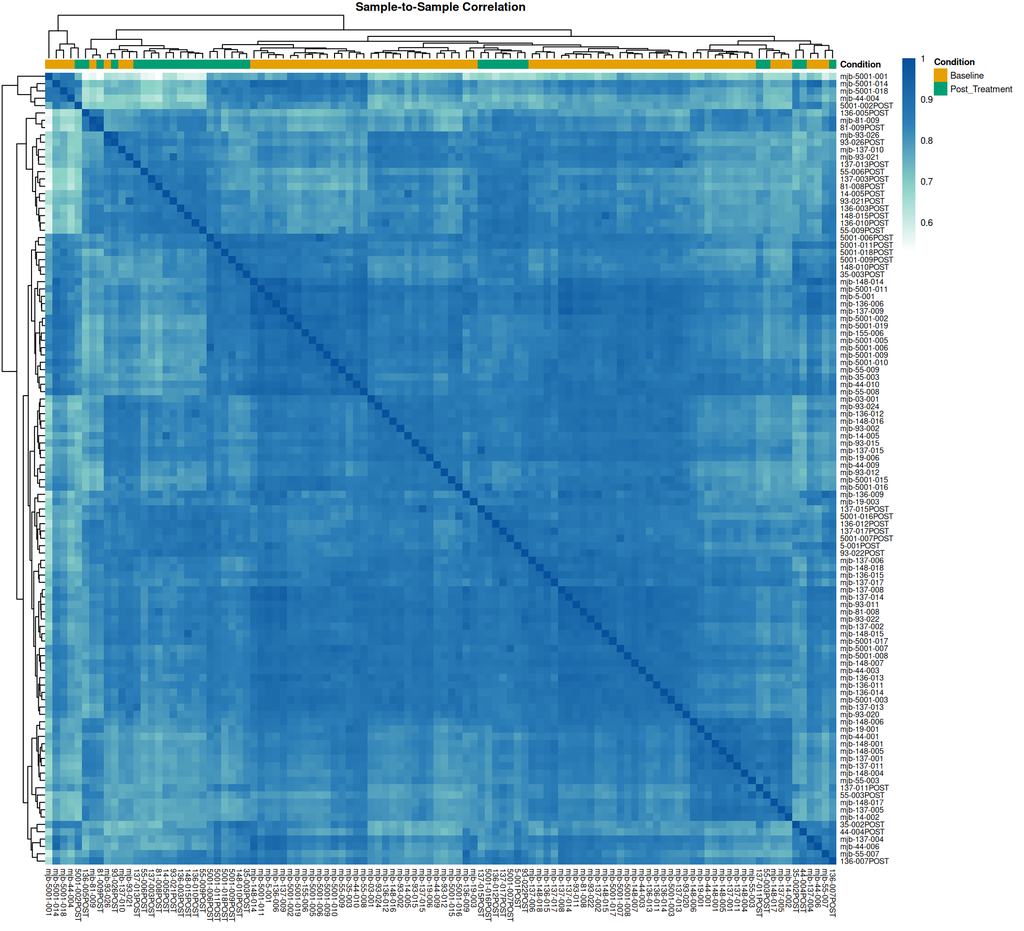

```r
# Calculate sample correlations
logcpm <- cpm(dge_filtered, log = TRUE, prior.count = 1)
cor_matrix <- cor(logcpm, method = "pearson")

# Annotation
annotation_col <- data.frame(
  Condition = samples$condition,
  row.names = rownames(samples)
)

ann_colors <- list(
  Condition = condition_colors
)

# Custom color gradient
cor_colors <- colorRampPalette(c("#FFFFFF", "#8DD3C7", "#2C7FB8", "#08519C"))(100)

# Plot correlation heatmap
pheatmap(
  cor_matrix,
  annotation_col = annotation_col,
  annotation_colors = ann_colors,
  color = cor_colors,
  display_numbers = FALSE,
  fontsize = 7,
  fontsize_row = 6,
  fontsize_col = 6,
  border_color = NA,
  main = "Sample-to-Sample Correlation",
  clustering_distance_rows = "euclidean",
  clustering_distance_cols = "euclidean",
  treeheight_row = 30,
  treeheight_col = 30
)
```

```r
# Summary statistics
baseline_samples <- rownames(samples)[samples$condition == "Baseline"]
post_samples <- rownames(samples)[samples$condition == "Post_Treatment"]

within_baseline <- cor_matrix[baseline_samples, baseline_samples]
within_baseline_cors <- within_baseline[upper.tri(within_baseline)]

within_post <- cor_matrix[post_samples, post_samples]
within_post_cors <- within_post[upper.tri(within_post)]

between_cors <- as.vector(cor_matrix[baseline_samples, post_samples])
```

**Figure 3: Genome-wide expression correlation between samples.** Heatmap shows Pearson correlation coefficients for all sample pairs based on normalized log-CPM values. Samples are hierarchically clustered and annotated by condition (orange = baseline, green = post-treatment). Color intensity represents correlation strength (white = low, dark blue = high). The intermixed clustering pattern reflects the high similarity in overall expression profiles between conditions.

#### Pearson correlation summary

**Within baseline samples**, the mean Pearson correlation was  
0.849 ± 0.046,  
with values ranging from 0.565 to  
0.953.

**Within post-treatment samples**, the mean correlation was  
0.834 ± 0.046,  
with a range of 0.67 to  
0.913.

**Between baseline and post-treatment samples**, the mean correlation was  
0.812 ± 0.047,  
ranging from 0.528 to  
0.967.

The correlation heatmap reveals moderate intermixing of baseline and post-treatment samples in the hierarchical clustering, rather than forming distinct condition-specific blocks. This intermixing is explained by the similar correlation values across all sample comparisons: within-baseline correlations average 0.849 ± 0.046, within post-treatment correlations average 0.834 ± 0.046, and critically, between-condition correlations average 0.812 ± 0.047. The small difference between within-group (0.849, 0.834) and between-group (0.812) correlations—only about 0.02-0.04—is insufficient to drive clear hierarchical separation by treatment condition.

### Dispersion Estimation

After normalization, I estimate gene-wise biological variability (dispersion) for the differential expression model. Dispersion quantifies how much gene expression varies between biological replicates beyond what would be expected from technical noise alone.

```r
# Create design matrix
design <- model.matrix(~ 0 + condition, data = samples)
colnames(design) <- levels(samples$condition)

# Estimate dispersions
edge <- estimateDisp(dge_filtered, design)
```

#### Dispersion estimates

The **common dispersion** was  
0.4112, corresponding to a BCV of  
0.641.

The **trended dispersion** values ranged from  
0.2858 to  
0.6507.

The **tagwise dispersion** values ranged from  
0.0318 to  
7.8828.

The **median gene-wise BCV** was  
0.516.

#### Biological coefficient of variation (BCV)

The common BCV of 0.641 indicates moderate biological variability, typical for human tumour samples. This value can be interpreted as the coefficient of variation in true gene expression between biological replicates (after accounting for technical noise). The value of 0.641 is reasonable for human breast cancer biopsies, where patient-to-patient variability, tumour heterogeneity, and sampling variation all contribute to dispersion.

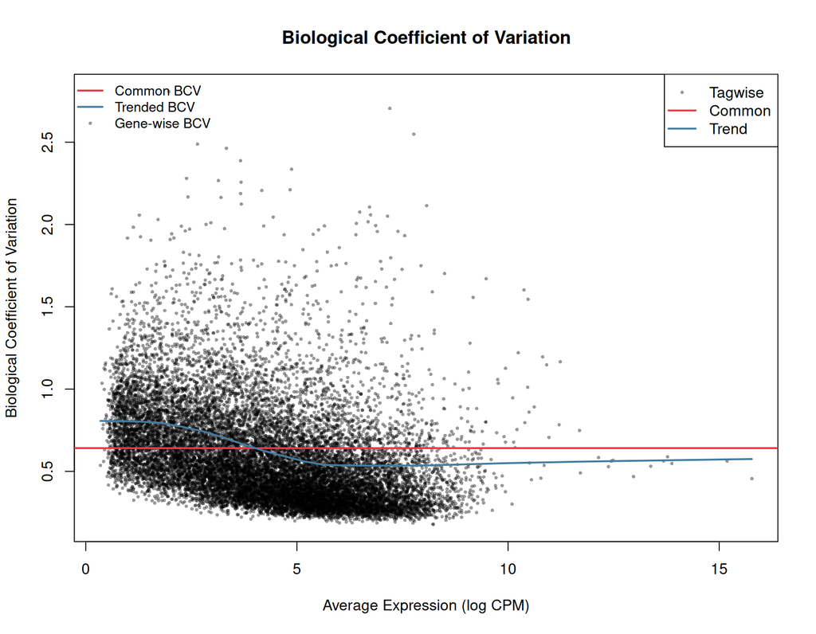

```r
plotBCV(edge,
        main = "Biological Coefficient of Variation",
        xlab = "Average Expression (log CPM)",
        ylab = "Biological Coefficient of Variation",
        pch = 16,
        cex = 0.5,
        col.tagwise = alpha("black", 0.4),
        col.common = "#E63946",
        col.trend = "#457B9D",
        lwd = 2,
        legend = FALSE)

legend("topleft",
       legend = c("Common BCV", "Trended BCV", "Gene-wise BCV"),
       col = c("#E63946", "#457B9D", alpha("black", 0.4)),
       lty = c(1, 1, NA),
       pch = c(NA, NA, 16),
       lwd = c(2, 2, NA),
       pt.cex = c(NA, NA, 0.5),
       bty = "n",
       cex = 0.9)
```

**Figure 4: Biological coefficient of variation across expression levels.** Each point represents one gene, plotted by average expression (x-axis) and biological variability (y-axis). The common dispersion (red line) gives the overall dataset BCV. The trended dispersion (blue curve) shows how variability decreases with higher expression—highly expressed genes have more precise measurements. Gene-wise dispersions (black points) are empirical Bayes-moderated estimates used in the statistical model.

### Sample Clustering

Multidimensional scaling (MDS) projects samples into 2D space based on their overall expression similarity, providing a complementary view to correlation analysis.

[figure not shown]

```r
plotMDS(
  dge_filtered,
  labels = NULL,
  col = c(PALETTE_BASELINE, PALETTE_POST)[as.numeric(samples$condition)],
  pch = 16,
  cex = 1.5,
  main = "Sample Clustering by Gene Expression Profile",
  gene.selection = "common"
)

legend("topleft",
       legend = c("Baseline", "Post-treatment"),
       col = c(PALETTE_BASELINE, PALETTE_POST),
       pch = 16,
       pt.cex = 1.5,
       bty = "n",
       cex = 1.1)

# Add variance explained annotation
mds_obj <- plotMDS(dge_filtered, plot = FALSE)
var_exp_1 <- round(mds_obj$var.explained[1] * 100, 1)
var_exp_2 <- round(mds_obj$var.explained[2] * 100, 1)

mtext(paste0("Leading Dim 1 explains ", var_exp_1, "% of variance; ",
             "Leading Dim 2 explains ", var_exp_2, "% of variance"),
      side = 3, line = 0.5, cex = 0.8, col = "grey40")
```

**Figure 5: Multidimensional scaling plot of sample relationships.** Each point is one sample, positioned based on similarity of its expression profile to all other samples. Distance between points reflects overall transcriptional difference based on the top 500 most variable genes. The two leading dimensions capture the major axes of variation in the dataset. Baseline samples are shown in orange, post-treatment samples in reen.

The partial separation pattern suggests that anti-fibrotic therapy induces measurable transcriptional changes in a subset of genes while leaving much of the transcriptome unchanged. This is consistent with a targeted therapeutic effect rather than global transcriptional reprogramming. The substantial overlap indicates that differential expression analysis will be essential to identify the specific genes affected by treatment, as overall expression profiles remain relatively similar between conditions.

## Differential Expression Testing

### Statistical Model

I use edgeR’s **quasi-likelihood (QL) framework** for differential expression testing. The QL approach:

- Models count data with a negative binomial distribution (appropriate for overdispersed count data)
- Estimates gene-wise dispersion with empirical Bayes shrinkage (borrowing information across genes)
- Uses quasi-likelihood F-tests rather than likelihood ratio tests (more conservative and better controls false positives)
- Accounts for uncertainty in dispersion estimates
- Controls for multiple testing using Benjamini-Hochberg FDR

The QL framework is more robust than older likelihood ratio test approaches, particularly for experiments with modest sample sizes, and has been shown to maintain better type I error control.

```r
# Fit quasi-likelihood model
fit <- glmQLFit(edge, design)

# Define contrasts
contrasts <- makeContrasts(
  Post_vs_Baseline = Post_Treatment - Baseline,
  levels = design
)

# Test for differential expression
qlf <- glmQLFTest(fit, contrast = contrasts[, "Post_vs_Baseline"])

# Extract results
de_results <- topTags(qlf, n = Inf)$table %>%
  rownames_to_column("gene")

# Preview top genes
de_results %>%
  dplyr::select(gene, logFC, logCPM, F, PValue, FDR) %>%
  head(12) %>%
  paged_table()
```

|  | gene | logFC | logCPM | F | PValue | FDR |
| --- | --- | --- | --- | --- | --- | --- |
| 1 | IPO7P2 | -5.213923 | 2.442489 | 294.4771 | 2.054553e-38 | 3.372138e-34 |
| 2 | HNRNPR | -1.634250 | 7.305097 | 355.6932 | 2.768161e-36 | 2.271691e-32 |
| 3 | MORF4L1P1 | -3.579417 | 4.883779 | 332.8359 | 5.565745e-35 | 3.045019e-31 |
| 4 | FAM3C2P | -4.005340 | 2.189717 | 267.6503 | 1.003277e-34 | 4.116695e-31 |
| 5 | SMARCA5 | -1.429868 | 6.523377 | 319.5465 | 2.405677e-34 | 7.896877e-31 |
| 6 | TPR | -1.707577 | 7.683585 | 317.8896 | 2.967197e-34 | 8.116768e-31 |
| 7 | PTGES3P1 | -4.411637 | 2.937110 | 273.5593 | 3.515861e-34 | 8.243690e-31 |
| 8 | DNAJB6P1 | -3.720701 | 3.653837 | 309.2428 | 4.346735e-34 | 8.917871e-31 |
| 9 | CALM2P2 | -3.424472 | 3.113980 | 280.7216 | 1.379040e-32 | 2.514910e-29 |
| 10 | RCN1P2 | -4.188321 | 1.472439 | 217.0436 | 9.151537e-32 | 1.374063e-28 |

[output cut: 2 more lines]

**Table 7: Top differentially expressed genes.** Genes ranked by statistical significance (FDR). Columns: gene symbol, log2 fold-change (positive = upregulated post-treatment, negative = downregulated), average expression level (logCPM), F-statistic, raw p-value, and FDR-adjusted p-value. Higher logCPM values indicate more reliably quantified genes.

### Multiple Testing Correction

```r
# Significance thresholds
fdr_threshold <- 0.05
fc_threshold <- 1  # log2 scale, so 1 = 2-fold change
```

### Threshold justification

An **FDR threshold** of 0.05 was used to control the false discovery rate at 5%.  
This threshold is appropriate for exploratory analysis and is more stringent than a nominal  
*p* < 0.05 threshold, which would be expected to yield approximately  
821 false positives.

A **fold-change threshold** of |log₂FC| > 1  
(corresponding to a 2-fold change) was applied to ensure biological relevance.  
A two-fold change is commonly used as a minimum cutoff, as smaller expression changes may be  
statistically significant but biologically subtle. In cancer biology, expression changes are  
typically larger and more pronounced.

With 16413 genes tested simultaneously, p-values are adjusted using the **Benjamini-Hochberg method** to control the false discovery rate (FDR). FDR < 0.05 means we expect fewer than 5% of genes called significant to be false positives—if we call 1000 genes significant at FDR < 0.05, we expect approximately 50 false positives. This is far more appropriate than using unadjusted p < 0.05, which would yield approximately 821 false positives in our dataset.

#### Fold-change threshold justification

While statistical significance (FDR < 0.05) ensures reproducibility, fold-change thresholds ensure biological relevance. A gene could be statistically significantly different but change only 1.1-fold—such small changes may be technically real but biologically subtle. In cancer research, 2-fold changes (|log2FC| > 1) are generally considered the minimum for biological significance, as they represent substantive shifts in gene expression that are more likely to affect cellular phenotypes and be detectable by validation methods like qPCR.

```r
# Count significant genes at different thresholds
n_p05 <- sum(de_results$PValue < 0.05, na.rm = TRUE)
n_fdr05 <- sum(de_results$FDR < 0.05, na.rm = TRUE)
n_fdr05_fc1 <- sum(de_results$FDR < 0.05 & abs(de_results$logFC) > 1, na.rm = TRUE)
n_fdr05_fc2 <- sum(de_results$FDR < 0.05 & abs(de_results$logFC) > 2, na.rm = TRUE)

# Direction of change
up_fdr05_fc1 <- sum(de_results$FDR < 0.05 & de_results$logFC > 1, na.rm = TRUE)
down_fdr05_fc1 <- sum(de_results$FDR < 0.05 & de_results$logFC < -1, na.rm = TRUE)

summary_stats <- data.frame(
  Threshold = c(
    "P-value < 0.05 (unadjusted)",
    "FDR < 0.05",
    "FDR < 0.05 & |log2FC| > 1",
    "  - Upregulated",
    "  - Downregulated",
    "FDR < 0.05 & |log2FC| > 2"
  ),
  `Genes` = c(
    n_p05,
    n_fdr05,
    n_fdr05_fc1,
    up_fdr05_fc1,
    down_fdr05_fc1,
    n_fdr05_fc2
  ),
  `Percent of Tested` = round(100 * c(
    n_p05,
    n_fdr05,
    n_fdr05_fc1,
    up_fdr05_fc1,
    down_fdr05_fc1,
    n_fdr05_fc2
  ) / nrow(de_results), 1),
  check.names = FALSE
)

paged_table(summary_stats)
```

[output not shown]

**Table 8: Differential expression summary at various thresholds.** Number and percentage of genes meeting different significance and fold-change criteria. The progression from unadjusted p-value to FDR to combined FDR+FC thresholds shows increasingly stringent filtering for both statistical confidence and biological magnitude.

At our chosen threshold (FDR < 0.05, |log2FC| > 1), we identify **1791 differentially expressed genes** (10.9% of tested genes), with 973 upregulated and 818 downregulated in post-treatment samples. This relatively balanced up/down ratio suggests that treatment induces complex transcriptional remodeling rather than global suppression or activation. The proportion of DE genes (~10.9%) is substantial, consistent with a treatment that significantly alters tumour biology while maintaining cell identity (i.e., cells remain recognizably breast cancer cells but with altered phenotype).

### Volcano Plot

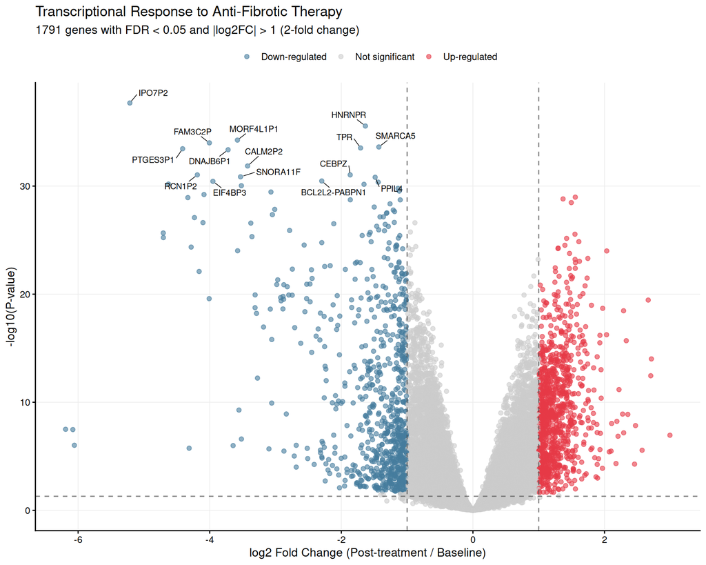

```r
# Classify genes by significance and direction
volcano_df <- de_results %>%
  mutate(
    regulation = case_when(
      FDR < fdr_threshold & logFC > fc_threshold ~ "Up-regulated",
      FDR < fdr_threshold & logFC < -fc_threshold ~ "Down-regulated",
      TRUE ~ "Not significant"
    )
  )

# Select top genes for labeling
top_genes_label <- volcano_df %>%
  filter(FDR < fdr_threshold & abs(logFC) > fc_threshold) %>%
  arrange(FDR) %>%
  slice_head(n = 15)

# Custom colors
volcano_colors <- c(
  "Up-regulated" = "#E63946",
  "Down-regulated" = "#457B9D",
  "Not significant" = "grey80"
)

# Plot
ggplot(volcano_df, aes(x = logFC, y = -log10(PValue))) +
  geom_point(aes(color = regulation), alpha = 0.6, size = 1.8) +
  scale_color_manual(values = volcano_colors) +
  geom_vline(xintercept = c(-fc_threshold, fc_threshold),
             linetype = "dashed", color = "grey30", alpha = 0.7) +
  geom_hline(yintercept = -log10(0.05),
             linetype = "dashed", color = "grey30", alpha = 0.7) +
  geom_text_repel(
    data = top_genes_label,
    aes(label = gene),
    size = 3,
    max.overlaps = 20,
    box.padding = 0.5,
    point.padding = 0.3,
    segment.size = 0.3,
    min.segment.length = 0
  ) +
  theme_classic(base_size = 12) +
  theme(
    legend.position = "top",
    panel.grid.major = element_line(color = "grey92", linewidth = 0.3)
  ) +
  labs(
    title = "Transcriptional Response to Anti-Fibrotic Therapy",
    subtitle = paste0(n_fdr05_fc1, " genes with FDR < ", fdr_threshold,
                      " and |log2FC| > ", fc_threshold, " (",
                      2^fc_threshold, "-fold change)"),
    x = "log2 Fold Change (Post-treatment / Baseline)",
    y = "-log10(P-value)",
    color = NULL
  )
```

**Figure 6: Genome-wide differential expression analysis.** Each point represents one gene, positioned by its fold-change (x-axis) and statistical significance (y-axis). Genes significantly up-regulated in post-treatment samples (FDR < 0.05, >2-fold) are shown in red, down-regulated genes in blue, and non-significant genes in grey. Dashed lines mark the significance threshold (horizontal: p = 0.05 unadjusted) and 2-fold change thresholds (vertical). The top 15 most significant genes meeting both thresholds are labeled.

### Expression Heatmap

To visualize expression patterns of the most differentially expressed genes, I create a heatmap showing row-normalized (z-scored) expression. Z-scoring enables visualization of relative expression patterns while removing the effect of absolute expression differences between genes.

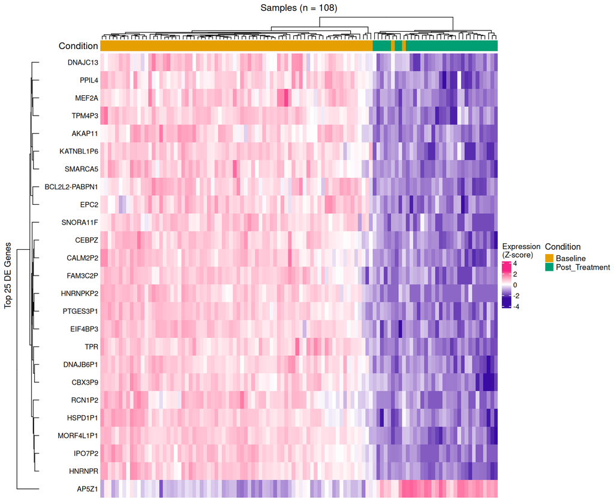

```r
# Select top 25 genes by combined FDR and fold-change
top25_genes <- de_results %>%
  filter(FDR < fdr_threshold & abs(logFC) > fc_threshold) %>%
  arrange(FDR, desc(abs(logFC))) %>%
  slice_head(n = 25) %>%
  pull(gene)

# Extract normalized expression
logcpm_all <- cpm(dge_filtered, log = TRUE, prior.count = 1)
heatmap_data <- logcpm_all[top25_genes, , drop = FALSE]

# Calculate row z-scores
heatmap_z <- t(scale(t(heatmap_data)))

# Color scale
col_fun <- colorRamp2(
  c(-2.5, 0, 2.5),
  c("#3A0CA3", "white", "#F72585")
)

# Column annotation
col_annot <- HeatmapAnnotation(
  Condition = samples$condition,
  col = list(Condition = condition_colors),
  annotation_name_side = "left",
  annotation_legend_param = list(
    Condition = list(
      title = "Condition",
      title_gp = gpar(fontsize = 11),
      labels_gp = gpar(fontsize = 10)
    )
  )
)

# Draw heatmap
Heatmap(
  heatmap_z,
  name = "Z-score",
  col = col_fun,
  top_annotation = col_annot,
  show_row_names = TRUE,
  row_names_gp = gpar(fontsize = 9),
  show_column_names = FALSE,
  cluster_rows = TRUE,
  cluster_columns = TRUE,
  row_names_side = "left",
  column_title = paste0("Samples (n = ", ncol(heatmap_z), ")"),
  row_title = "Top 25 DE Genes",
  row_title_side = "left",
  column_title_gp = gpar(fontsize = 12),
  row_title_gp = gpar(fontsize = 11),
  heatmap_legend_param = list(
    title = "Expression\n(Z-score)",
    title_gp = gpar(fontsize = 10),
    labels_gp = gpar(fontsize = 9),
    grid_height = unit(4, "mm"),
    grid_width = unit(4, "mm")
  )
)
```

**Figure 7: Expression patterns of top differentially expressed genes.** Heatmap displays the 25 genes with strongest combined evidence of differential expression (lowest FDR and highest fold-changes). Each row is one gene, each column one sample. Colors represent z-scored expression (purple = below average, white = average, pink = above average for that gene across all samples). Z-scoring normalizes each gene to mean = 0, SD = 1, allowing genes with different absolute expression levels to be visualized on the same color scale. Samples are hierarchically clustered and annotated by condition (color bar: orange = baseline, green = post-treatment).

The heatmap reveals near perfect sample clustering by treatment condition with the dendrogram showing almost complete separation of baseline (orange annotation bar) and post-treatment (green annotation bar) samples with minimal intermixing. This demonstrates that the top 25 differentially expressed genes effectively capture the primary biological signal distinguishing the two conditions. Within the gene dimension (rows), hierarchical clustering reveals co-expression patterns: genes that cluster together show similar regulatory responses to treatment and may share biological functions or regulatory mechanisms.

## Summary and Interpretation

**Data quality validation:** The high within-condition correlation (baseline mean = 0.849, post-treatment mean = 0.834) and consistent clustering validate excellent data quality and support the robustness of these findings. The biological coefficient of variation (0.641) is within the expected range for human clinical samples, indicating appropriate dispersion modeling.

**Biological interpretation:** The identification of both upregulated and downregulated genes (ratio of 973:818) suggests complex remodeling of the tumour transcriptome rather than global transcriptional suppression or activation. This pattern is consistent with treatment inducing a phenotypic shift in tumour cells—potentially from a proliferative, fibrotic state toward an altered state that may be more susceptible to immune recognition or less invasive. The proportion of genes affected (~10.9% of the transcriptome) indicates substantial biological remodeling while maintaining cell identity.

**Clinical relevance:** These findings provide molecular insights into how anti-fibrotic therapy reshapes breast cancer transcriptomes, which could inform development of predictive biomarkers for treatment response and reveal mechanisms of therapy resistance. The top differentially expressed genes represent candidates for further validation and mechanistic investigation.

## Responses to Assignment Questions

1. **Why is the dataset of interest to you?**

   For this project, I wanted to work with a dataset that felt both personally interesting and scientifically meaningful. Cancer drug research is an area that I have been working in for my BCB430 project, and I was interested in exploring some similar datasets. Furthermore, cancer drug research directly impacts patient outcomes. This dataset offers molecular insights into how anti-fibrotic therapy reshapes the breast cancer transcriptome, potentially revealing mechanisms of treatment response and resistance that could inform future therapeutic strategies.
2. **What are the control and test conditions of the dataset?**

   Control: Baseline tumour biopsies collected before any treatment intervention (n=76).

   Test: Post-treatment samples collected after neoadjuvant therapy with paclitaxel ± nintedanib (n=32).

   This design captures treatment-induced transcriptional changes.
3. **How many samples in each of the conditions of your dataset?**

   76 baseline samples and 32 post-treatment samples (total n = 108). This sample size provides good statistical power for detecting differential expression, as evidenced by the detection of 1791 genes with FDR < 0.05 and >2-fold change.
4. **Were there expression values that were not unique for specific genes? How did you handle these?**

   Yes, 19 HUGO symbols mapped to multiple Ensembl IDs, representing different transcript variants or overlapping genomic loci. I aggregated these by summing read counts across all Ensembl IDs for each HUGO symbol. This approach captures total gene-level expression and maintains count-based statistical properties required for edgeR while ensuring one-to-one mapping between gene symbols and expression values.
5. **Were there expression values that could not be mapped to current HUGO symbols?**

   1250 genes (2.1%) could not be mapped to the biomaRt database and were excluded from analysis. These likely represent deprecated Ensembl IDs, non-coding RNAs without official nomenclature, or genes removed from recent annotation versions. An additional ~30% of genes mapped to biomaRt but lacked official HUGO symbols (often non-coding RNAs or predicted genes), which is expected for comprehensive RNA-seq datasets.
6. **Were there any outliers in your dataset? How were they handled in the originating paper? How many outliers were removed?**

   Final dataset: **16413 genes** across **108 samples** after mapping to HUGO symbols and filtering lowly expressed genes. This represents 27% of the original raw count matrix and comprises reliably detectable, well-annotated genes with sufficient expression for robust statistical testing—the functionally active portion of the transcriptome.

## References

Chen, Yunshun, Lizhong Chen, Aaron T L Lun, Pedro Baldoni, and Gordon K Smyth. 2025. “edgeR V4: Powerful Differential Analysis of Sequencing Data with Expanded Functionality and Improved Support for Small Counts and Larger Datasets.” *Nucleic Acids Research* 53 (2): gkaf018. https://doi.org/10.1093/nar/gkaf018.

Davis, Sean, and Paul Meltzer. 2007. “GEOquery: A Bridge Between the Gene Expression Omnibus (GEO) and BioConductor.” *Bioinformatics* 14: 1846–47. https://doi.org/10.1093/bioinformatics/btm254.

Durinck, Steffen, Yves Moreau, Arek Kasprzyk, Sean Davis, Bart De Moor, Alvis Brazma, and Wolfgang Huber. 2005. “BioMart and Bioconductor: A Powerful Link Between Biological Databases and Microarray Data Analysis.” *Bioinformatics* 21: 3439–40.

Evans, Ciaran, Johanna Hardin, and Daniel M Stoebel. 2017. “Selecting Between-Sample RNA-Seq Normalization Methods from the Perspective of Their Assumptions.” *Briefings in Bioinformatics* 19 (5): 776–92. https://doi.org/10.1093/bib/bbx008.

Gu, Zuguang. 2022. “Complex Heatmap Visualization.” *iMeta*. https://doi.org/10.1002/imt2.43.

Gu, Zuguang, Lei Gu, Roland Eils, Matthias Schlesner, and Benedikt Brors. 2014. “Circlize Implements and Enhances Circular Visualization in r.” *Bioinformatics*. https://doi.org/10.1093/bioinformatics/btu393.

Morgan, Martin, and Marcel Ramos. 2025. *BiocManager: Access the Bioconductor Project Package Repository*. https://bioconductor.github.io/BiocManager/.

Müller, Kirill, and Hadley Wickham. 2025. *Tibble: Simple Data Frames*. https://tibble.tidyverse.org/.

Pedersen, Thomas Lin. 2025. *Patchwork: The Composer of Plots*. https://doi.org/10.32614/CRAN.package.patchwork.

Robinson, Mark D., and Alicia Oshlack. 2010. “A Scaling Normalization Method for Differential Expression Analysis of RNA-Seq Data.” *Genome Biology* 11 (3): R25. https://doi.org/10.1186/gb-2010-11-3-r25.

Slowikowski, Kamil. 2024. *Ggrepel: Automatically Position Non-Overlapping Text Labels with ’Ggplot2’*. https://doi.org/10.32614/CRAN.package.ggrepel.

Wickham, Hadley. 2016. *Ggplot2: Elegant Graphics for Data Analysis*. Springer-Verlag New York. https://ggplot2.tidyverse.org.

Wickham, Hadley, Romain François, Lionel Henry, Kirill Müller, and Davis Vaughan. 2023. *Dplyr: A Grammar of Data Manipulation*. https://doi.org/10.32614/CRAN.package.dplyr.

Wickham, Hadley, Jim Hester, and Jennifer Bryan. 2025. *Readr: Read Rectangular Text Data*. https://doi.org/10.32614/CRAN.package.readr.

Wickham, Hadley, Davis Vaughan, and Maximilian Girlich. 2024. *Tidyr: Tidy Messy Data*. https://doi.org/10.32614/CRAN.package.tidyr.

Xie, Yihui. 2014. “Knitr: A Comprehensive Tool for Reproducible Research in R.” In *Implementing Reproducible Computational Research*, edited by Victoria Stodden, Friedrich Leisch, and Roger D. Peng. Chapman; Hall/CRC.

Xie, Yihui, Christophe Dervieux, and Emily Riederer. 2020. *R Markdown Cookbook*. Boca Raton, Florida: Chapman; Hall/CRC. https://bookdown.org/yihui/rmarkdown-cookbook.